# HW4 Po-Chun Chen N11957611

### Chapter 6

#### 6.5

##### a.

Correctly state the hypotheses in terms of population parameters

$H_0$ : O2 below the town is the same as O2 above the town  
$H_A$ : o2 below the town is lower than O2 above the town  
$\alpha$ = 0.05

##### b.

Use R to calculate sample means and variances.

```r
library(asbio)
data("dO2")
mean_below<- mean(dO2$O2[dO2$location=='Below'])
print(mean_below)
```

```
## [1] 4.74
```

```r
mean_above<- mean(dO2$O2[dO2$location=='Above'])
print(mean_above)
```

```
## [1] 4.92
```

```r
var_below<-var(dO2$O2[dO2$location=='Below'])
print(var_below)
```

```
## [1] 0.1025714
```

```r
var_above<-var(dO2$O2[dO2$location=='Above'])
print(var_above)
```

```
## [1] 0.02457143
```

##### c.

Calculate the pooled variance.

```r
pool_var<- (14*var_below+14*var_above)/28
print(pool_var)
```

```
## [1] 0.06357143
```

##### d.

Calculate the test statistic.

```r
test_sta <- (mean_above-mean_below)/(sqrt(pool_var)*sqrt(2/15))
print(test_sta)
```

```
## [1] 1.955114
```

##### e.

Calculate the P-value.

```r
p_value<-pt(-abs(test_sta),df=28)
print(p_value)
```

```
## [1] 0.03030912
```

##### f.

Verify your test result by running the whole test in R. Attach this output to homework.

```r
with(dO2, t.test(O2~location, var.equal = TRUE,alternative = "greater"))
```

```
##
##  Two Sample t-test
##
## data:  O2 by location
## t = 1.9551, df = 28, p-value = 0.03031
## alternative hypothesis: true difference in means is greater than 0
## 95 percent confidence interval:
##  0.02338329        Inf
## sample estimates:
## mean in group Above mean in group Below
##                4.92                4.74
```

##### f.

State your conclusions

The p-value is 0.0303. The result is significant at p < 0.05. Therefore, we can reject the null hypothesis and support the alternative hypothesis.

#### 6.6

Polychlorinated biphenyls (PCBs) are a group of synthetic oil-like chemicals whose toxicity was first recognized in the 1970s. Until then, they were widely used as insulation in electrical equipment, particularly transformers. PCB concentrations in bird eggs helps researchers quantify bioaccumulation of PCBs in ecosystems. The same set of thirteen sites in the Great Lakes were selected for a study to quantify PCB concentrations in 1982 and 1996 (Hughes et al. 1998). At each site, 9-13 American herring gull (Larus smithsonianus) eggs were randomly collected and tested for PCB content. Test to see if 1996 levels were lower than 1982 levels. The data are in the asbio dataframe PCB.

##### a.

State the null and alternative hypotheses.

$H_0$ : 1996 levels were the same as 1982 levels  
$H_A$ : 1996 levels were lower than 1982 levels  
$\alpha$ = 0.05

##### b.

Report the means and variances for the 1982 and 1996 values.

```r
library(asbio)
data("PCB")
mean_1982<- mean(PCB$level[PCB$year=='1982'])
print(mean_1982)
```

```
## [1] 54.32769
```

```r
mean_1996<- mean(PCB$level[PCB$year=='1996'])
print(mean_1996)
```

```
## [1] 15.52462
```

```r
var_1982<-var(PCB$level[PCB$year=='1982'])
print(var_1982)
```

```
## [1] 245.0279
```

```r
var_1996<-var(PCB$level[PCB$year=='1996'])
print(var_1996)
```

```
## [1] 35.56414
```

##### c.

Considering that each pair of measurements for 1982 and 1996 were taken at the same site, which t-test is appropriate? Explain your answer.

A: paired t-test is used to compared two population means where you have two samples in which observations in one sample can be paired with observations in the other sample

##### d.

Is this a one-sided or a two-sided test?

A: one sided t-test

##### e.

Carry out the t-test in R, and report the p-value.

```r
number_1982<-c(PCB$level[PCB$nest[1:13]])
number_1996<-c(PCB$level[14:26])

number_difference<-number_1982-number_1996
sum_difference<-sum(number_difference)
sum_squared<-sum(number_difference**2)

t_score<-mean(number_difference)/sd(number_difference)*sqrt(13)


p_value2<-pt(-abs(t_score),df=12)
print(p_value2)
```

```
## [1] 5.048626e-08
```

##### f.

What is your conclusion?

The p-value is 5.048626e-08. The result is significant at p < 0.05. Therefore, we can reject the null hypothesis and support the alternative hypothesis.

#### 3

In a clinic, a sample of patients with cystic fibrosis are studied. Researchers were able to measure the weights of 9 patients from this subpopulation. Assume the weights are normally-distributed in the population. The mean of their sample was 56.4 kilograms with a (sample) standard deviation of 14.3 kilograms. We want to test the null hypothesis that the mean weight of this sample of patients is equal to the population mean of 73.6 kg. Compute a p-value using a parametric method.  
(Show your working including test statistic and p-value, and interpret your p-value).

```r
sample_mean<- 56.4
sample_sd<- 14.3
```

```r
sd_correct<- 14.3/sqrt(9)
t_score2<- (56.4-73.6)/sd_correct

p_value3<-2*pt(-abs(t_score2),df=8)
print(p_value3)
```

```
## [1] 0.006897755
```

The p-value is 0.006897755. The result is significant at p < 0.05. However, it is not significant at p<0.001. Therefore, we should be careful while interpret the conclusion. Still, the p value is small and we can reject the null hypothesis if we set the $\alpha$ as 0.05

#### 4

Define a “null distribution”. How does it differ from the sampling distributions we have used for estimation of 95% confidence intervals so far in this course? What is a null distribution used to calculate?

A: In statistical hypothesis testing, the null distribution is the probability distribution when the null hypothesis is true. As for the sampling distribution, you have to understand from the context, the sampling distribution may refer to the statistic under the null hypothesis, but in another context it could refer to the sampling distribution of a statistic under an alternative hypothesis. It is usually used to calculate the p-value and decided if we need to reject the null hypothesis.

#### 5

In a randomized clinical trial comparing a new analgesic drug with a placebo on the pain caused by cervical osteoarthritis, 11 of 14 patients in the new drug group reported an improvement in pain compared with 4 of the 13 receiving placebo treatment.

##### i

Estimate the proportions for each group, and compute the standard error and 95% confidence intervals. You should not use a compute-intensive method (hint:you can compute the Clopper-Pearson 95% CI using binom.test()).

```r
standard_error_drug <- sqrt((11/14*3/14)/14)
print(standard_error_drug)
```

```
## [1] 0.1096642
```

```r
#confidence_95_left<-(11/14)-qt(0.975,df=13)*standard_error_drug
#confidence_95_right<-(11/14)+qt(0.975,df=13)*standard_error_drug

#confidence_95_left<-(11/14)-1.96*standard_error_drug
#confidence_95_right<-(11/14)+1.96*standard_error_drug

binom.test(x = 11,n = 14,p=11/14,conf.level = 0.95,alternative = "two.sided")
```

```
##
##  Exact binomial test
##
## data:  11 and 14
## number of successes = 11, number of trials = 14, p-value = 1
## alternative hypothesis: true probability of success is not equal to 0.7857143
## 95 percent confidence interval:
##  0.4920243 0.9534207
## sample estimates:
## probability of success
##              0.7857143
```

```r
standard_error_placebo <- sqrt((4/13*9/13)/13)
print(standard_error_placebo)
```

```
## [1] 0.1280077
```

```r
#confidence_95_left<-(4/13)-qt(0.975,df=12)*standard_error_placebo
#confidence_95_right<-(4/13)+qt(0.975,df=12)*standard_error_placebo

#confidence_95_left<-(4/13)-1.96*standard_error_placebo
#confidence_95_right<-(4/13)+1.96*standard_error_placebo

binom.test(x = 4,n = 13,conf.level = 0.95,alternative = "two.sided")
```

```
##
##  Exact binomial test
##
## data:  4 and 13
## number of successes = 4, number of trials = 13, p-value = 0.2668
## alternative hypothesis: true probability of success is not equal to 0.5
## 95 percent confidence interval:
##  0.09092039 0.61426166
## sample estimates:
## probability of success
##              0.3076923
```

Plot two bar graphs, showing the standard errors and 95% confidence intervals, respectively, on the plot. What is your interpretation of the plot with respect to the significance of the difference between the groups.

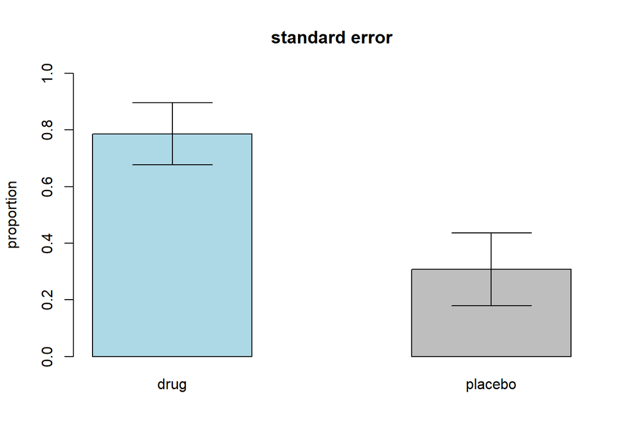

```r
library(gplots)
m1 = 11/14
m2 = 4/13
pulse_mean = cbind(drug=m1,placebo=m2)
pulse_sde = cbind(drug=standard_error_drug,men=standard_error_placebo)
mp <- barplot2(pulse_mean,width = 0.25,beside= T, col =c("lightblue","grey"),ylim= c(0,1),plot.ci = TRUE, ci.l = pulse_mean-pulse_sde, ci.u = pulse_mean+pulse_sde,ylab = "proportion",main = "standard error")
```

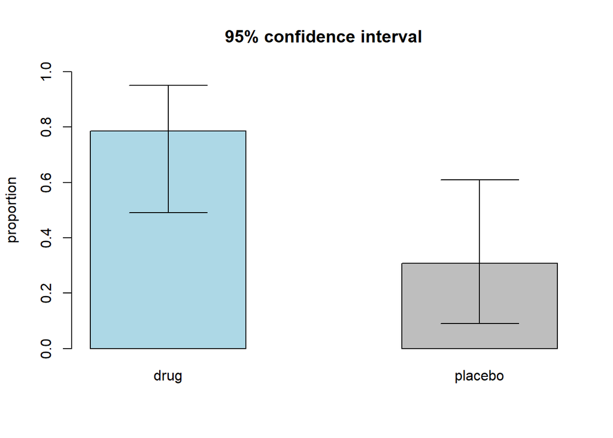

```r
mp <- barplot2(pulse_mean,width = 0.25,beside= T, col =c("lightblue","grey"),ylim= c(0,1),plot.ci = TRUE, ci.l = cbind(0.49,0.09), ci.u = cbind(0.95,0.61),ylab = "proportion",main = "95% confidence interval")
```

The first graph (standard error) shows that the error bar do not overlap with each other. Here, we can suggest that two mean can be different. We still need to confirm the differenct by the p-value and comparing the two proportion. However, in the second graph (95% confidence interval), the error bars are overlap. We still can not draw the conclusion that two tests are significantly difference. Also, we need to further confirm by p-value of the two tests. In conclusion, the drug plays an important role in releasing pain is still unknown.

##### ii

Using a Monte Carlo simulation in R (a compute-intensive method), compute the standard errors of the estimated proportions.Compare your results with the standard errors calculated directly from the binomial distribution, as computed in the above question.  
Hint:sample(c(“Y”, “N”), size = 14, prob = c(11/14,3/14), replace = TRUE)in R will generate a single simulated experimental results for the experimental group, where Y = had improvement, and N = no improvement.

```r
x<-matrix(nrow=1000,ncol=14)
for (i in 1:1000)
{
  x[i,]<-sample(c("Y", "N"), size = 14, prob = c(11/14,3/14), replace = TRUE)
}
prob<-c()
for (i in 1:1000)
{
  prob[i]<-sum(x[i,]=='Y')/14
}
sd(prob)
```

```
## [1] 0.1124203
```

```r
x<-matrix(nrow=1000,ncol=13)
for (i in 1:1000)
{
  x[i,]<-sample(c("Y", "N"), size = 13, prob = c(4/13,9/13), replace = TRUE)
}
prob2<-c()
for (i in 1:1000)
{
  prob2[i]<-sum(x[i,]=='Y')/13
}
sd(prob2)
```

```
## [1] 0.1266517
```

The results are similar to the previous parametric method.